# EXAMEN PRÁCTICO MÓDULO 2 - SECCIÓN B

Yulia Frenkel

14 03 2020

## Datos a utilizar

Usaremos los datos contenidos en el fichero Retail_Online.xlsx que estará accesible en el aula virtual. Este fichero contiene un gran conjunto de transacciones online durante un largo período de tiempo y desde diferentes países. El conjunto contiene estas variables: InvoiceNo: Número de factura. StockCode: Código de Stock. Description: Descripción del Item. Quantity: Cantidad de producto comprado. InvoiceDate: Fecha de la compra. UnitPrice: Precio unitario. CustomerID: Id del cliente. Country: País desde el que se realiza la transacción.

## Análisis

El objetivo del ejercicio es analizar este conjunto. La sintaxis de dplyr, tidyr, la capacidad gráfica de ggplot2 o la de análisis de data.table será de gran ayuda. El análisis incluirá enfoques numéricos (valores medios, máximos, etc) y gráficos que permitan de forma visual determinar el comportamiento o relaciones de diferentes variables. El análisis debiera de ofrecer detalles de al menos sobre (ejemplos muy inmediatos y no exhaustivos): Ventas por páis, por fecha, por cliente, ticket medio. Con las fechas y los clientes, se puede calcular cosas como el tiempo medio entre compras, si este tiempo medio se mantiene, fluctúa. Cualquier otro análisis adicional será valorado.

## Preprocesamiento de datos

Cree una variable agregada llamada Amount, multiplicando Cantidad por Precio, que da la cantidad total de dinero gastado por producto / artículo en cada transacción. Se supone que la cantidad variable representa los ingresos por ventas. Separe la variable InvoiceDate en dos variables Fecha y Hora. Esto permite que las diferentes transacciones creadas por el mismo consumidor el mismo día pero en diferentes momentos se traten por separado.

```r
library(tidyverse)
library(lubridate)
setwd("C:")
getwd()
```

```
## [1] "C:/Users/rsm_000/Desktop"
```

```r
Retail<- read.csv("Retail.csv", sep = ";", header = TRUE)
Retail <- na.omit(Retail)#eliminar registros en data.frame que contienen valores NA.
# cambiamos el tipo de variables
Retail$UnitPrice<-as.numeric(Retail$UnitPrice)

#adjuntamos nuevo variable
Retail$Amount <-Retail$Quantity*Retail$UnitPrice
#compartimos fecha y hora
Retail$InvoiceDate<- strptime(Retail$InvoiceDate,"%m.%d.%Y %H:%M")
Retail$InvoiceTime =format(Retail$InvoiceDate, "%H")
Retail$InvoiceDate <-as.Date(Retail$InvoiceDate, "%m/%d/%Y")
Retail <-filter(Retail, Quantity>0 & UnitPrice > 0 & !is.na(InvoiceDate))
str(Retail)
```

```
## 'data.frame':    168649 obs. of  10 variables:
##  $ InvoiceNo  : Factor w/ 25900 levels "536365","536366",..: 1 1 1 1 1 1 1 2 2 3 ...
##  $ StockCode  : Factor w/ 4070 levels "10002","10080",..: 3538 2795 3045 2986 2985 1663 801 1548 1547 3306 ...
##  $ Description: Factor w/ 4224 levels ""," 4 PURPLE FLOCK DINNER CANDLES",..: 4027 4035 932 1959 2980 3235 1573 1698 1695 259 ...
##  $ Quantity   : int  6 6 8 6 6 2 6 6 6 32 ...
##  $ InvoiceDate: Date, format: "2010-01-12" "2010-01-12" ...
##  $ UnitPrice  : num  690 991 698 991 991 ...
##  $ CustomerID : int  17850 17850 17850 17850 17850 17850 17850 17850 17850 13047 ...
##  $ Country    : Factor w/ 38 levels "Australia","Austria",..: 36 36 36 36 36 36 36 36 36 36 ...
##  $ Amount     : num  4140 5946 5584 5946 5946 ...
##  $ InvoiceTime: chr  "08" "08" "08" "08" ...
##  - attr(*, "na.action")= 'omit' Named int  623 1444 1445 1446 1447 1448 1449 1450 1451 1452 ...
##   ..- attr(*, "names")= chr  "623" "1444" "1445" "1446" ...
```

```r
head(Retail)
```

```
##   InvoiceNo StockCode                         Description Quantity InvoiceDate
## 1    536365    85123A  WHITE HANGING HEART T-LIGHT HOLDER        6  2010-01-12
## 2    536365     71053                 WHITE METAL LANTERN        6  2010-01-12
## 3    536365    84406B      CREAM CUPID HEARTS COAT HANGER        8  2010-01-12
## 4    536365    84029G KNITTED UNION FLAG HOT WATER BOTTLE        6  2010-01-12
## 5    536365    84029E      RED WOOLLY HOTTIE WHITE HEART.        6  2010-01-12
## 6    536365     22752        SET 7 BABUSHKA NESTING BOXES        2  2010-01-12
##   UnitPrice CustomerID        Country Amount InvoiceTime
## 1       690      17850 United Kingdom   4140          08
## 2       991      17850 United Kingdom   5946          08
## 3       698      17850 United Kingdom   5584          08
## 4       991      17850 United Kingdom   5946          08
## 5       991      17850 United Kingdom   5946          08
## 6      1456      17850 United Kingdom   2912          08
```

```r
summary(Retail)
```

```
##    InvoiceNo        StockCode                                  Description
##  580727 :   529   85123A :   908   WHITE HANGING HEART T-LIGHT HOLDER:   901
##  575607 :   377   22423  :   741   REGENCY CAKESTAND 3 TIER          :   741
##  570488 :   353   85099B :   687   JUMBO BAG RED RETROSPOT           :   687
##  569246 :   285   84879  :   596   ASSORTED COLOUR BIRD ORNAMENT     :   596
##  562031 :   277   47566  :   584   PARTY BUNTING                     :   584
##  543040 :   259   20725  :   561   LUNCH BAG RED RETROSPOT           :   561
##  (Other):166569   (Other):164572   (Other)                           :164579
##     Quantity         InvoiceDate           UnitPrice        CustomerID
##  Min.   :    1.00   Min.   :2010-01-12   Min.   :   2.0   Min.   :12347
##  1st Qu.:    2.00   1st Qu.:2011-03-05   1st Qu.:  99.0   1st Qu.:13881
##  Median :    6.00   Median :2011-06-09   Median : 145.0   Median :15192
##  Mean   :   13.08   Mean   :2011-05-15   Mean   : 494.2   Mean   :15295
##  3rd Qu.:   12.00   3rd Qu.:2011-09-06   3rd Qu.: 710.0   3rd Qu.:16873
##  Max.   :80995.00   Max.   :2011-12-10   Max.   :1603.0   Max.   :18287
##
##            Country           Amount         InvoiceTime
##  United Kingdom:150500   Min.   :       2   Length:168649
##  France        :  3914   1st Qu.:     594   Class :character
##  Germany       :  3718   Median :    1265   Mode  :character
##  EIRE          :  2802   Mean   :    3891
##  Spain         :   990   3rd Qu.:    3462
##  Belgium       :   848   Max.   :53537695
##  (Other)       :  5877
```

## El análisis incluirá enfoques numéricos (valores medios, máximos, etc) y gráficos que permitan de forma visual determinar el comportamiento o relaciones de diferentes variables.

```r
# Sorted by max value Amount  of "Country y CustomerID"
Retail %>%
  group_by(Country, CustomerID) %>%
  summarize(
    num_val = n(),
    Amount_max = max(Amount),
    Amount_med = mean(Amount),
    Amount_std = sd(Amount)
  ) %>%
  arrange(desc(Amount_max))
```

```
## # A tibble: 2,999 x 6
## # Groups:   Country [33]
##    Country        CustomerID num_val Amount_max Amount_med Amount_std
##    <fct>               <int>   <int>      <dbl>      <dbl>      <dbl>
##  1 United Kingdom      16446       1   53537695  53537695        NaN
##  2 United Kingdom      15749       5    2064582   1097440.    660033.
##  3 United Kingdom      17450     105    1255752     82474.    202459.
##  4 Japan               12755       4    1026720    257427     512862.
##  5 United Kingdom      15195       1     979992    979992        NaN
##  6 United Kingdom      16210      72     951360     58128.    155548.
##  7 United Kingdom      18102     232     816000    131712.    161384.
##  8 United Kingdom      16333      30     703800     83064     140453.
##  9 United Kingdom      16000       9     610080    211313.    217807.
## 10 United Kingdom      12931      62     506688     62624.     87749.
## # ... with 2,989 more rows
```

```r
# Sorted by max value Quantity  of "Country y CustomerID"
Retail %>%
  group_by(Country, CustomerID) %>%
  summarize(
    num_val = n(),
    Quantity_max = max(Quantity),
    Quantity_med = mean(Quantity),
    Quantity_std = sd(Quantity)
  ) %>%
  arrange(desc(Quantity_max))
```

```
## # A tibble: 2,999 x 6
## # Groups:   Country [33]
##    Country        CustomerID num_val Quantity_max Quantity_med Quantity_std
##    <fct>               <int>   <int>        <int>        <dbl>        <dbl>
##  1 United Kingdom      16446       1        80995       80995          NaN
##  2 United Kingdom      15749       5         3114        1803.         910.
##  3 United Kingdom      16308       2         3000        2500          707.
##  4 United Kingdom      12931      62         2880         374.         436.
##  5 United Kingdom      16754       2         2880        2140         1047.
##  6 United Kingdom      16333      30         2592         757.         586.
##  7 United Kingdom      16029     114         2400         199.         325.
##  8 United Kingdom      15299       5         1824         493.         747.
##  9 United Kingdom      12875       1         1728        1728          NaN
## 10 United Kingdom      13694     183         1600         136.         184.
## # ... with 2,989 more rows
```

```r
# Sorted by max value Amount of "Description"
Retail %>%
  group_by(Description) %>%
  summarize(
    num_val = n(),
    Amount_max = max(Amount),
    Amount_med = mean(Amount),
    Amount_std = sd(Amount)
  ) %>%
  arrange(desc(Amount_max))
```

```
## # A tibble: 3,686 x 5
##    Description                          num_val Amount_max Amount_med Amount_std
##    <fct>                                  <int>      <dbl>      <dbl>      <dbl>
##  1 "PAPER CRAFT , LITTLE BIRDIE"              1   53537695  53537695        NaN
##  2 "FAIRY CAKE FLANNEL ASSORTED COLOUR"      79    2064582     29727.    231921.
##  3 "WHITE HANGING HEART T-LIGHT HOLDER"     901    1331700     14213.     66991.
##  4 "HEART OF WICKER LARGE"                  383    1255752      9407.     68202.
##  5 "ROUND SNACK BOXES SET OF 4 FRUITS "     194    1026720     12027.     74165.
##  6 "METAL SIGN TAKE IT OR LEAVE IT "        168     979992      9612.     75502.
##  7 "BLACK RECORD COVER FRAME"               139     951360     46966.    116920.
##  8 "DOORMAT FAIRY CAKE"                     111     921920     19100.     94670.
##  9 "TEA TIME TEA TOWELS "                     1     897000    897000        NaN
## 10 "RED HANGING HEART T-LIGHT HOLDER"       305     841940     10388.     54511.
## # ... with 3,676 more rows
```

```r
# Sorted by max value Quantity of "Description"
Retail %>%
  group_by(Description) %>%
  summarize(
    num_val = n(),
    Quantity_max = max(Amount),
    Quantity_med = mean(Amount),
    Quantity_std = sd(Amount)
  ) %>%
  arrange(desc(Quantity_max))
```

```
## # A tibble: 3,686 x 5
##    Description                    num_val Quantity_max Quantity_med Quantity_std
##    <fct>                            <int>        <dbl>        <dbl>        <dbl>
##  1 "PAPER CRAFT , LITTLE BIRDIE"        1     53537695    53537695          NaN
##  2 "FAIRY CAKE FLANNEL ASSORTED ~      79      2064582       29727.      231921.
##  3 "WHITE HANGING HEART T-LIGHT ~     901      1331700       14213.       66991.
##  4 "HEART OF WICKER LARGE"            383      1255752        9407.       68202.
##  5 "ROUND SNACK BOXES SET OF 4 F~     194      1026720       12027.       74165.
##  6 "METAL SIGN TAKE IT OR LEAVE ~     168       979992        9612.       75502.
##  7 "BLACK RECORD COVER FRAME"         139       951360       46966.      116920.
##  8 "DOORMAT FAIRY CAKE"               111       921920       19100.       94670.
##  9 "TEA TIME TEA TOWELS "               1       897000      897000          NaN
## 10 "RED HANGING HEART T-LIGHT HO~     305       841940       10388.       54511.
## # ... with 3,676 more rows
```

## Ventas por páis, por fecha, por cliente, ticket medio.

```r
# Ventas por páis
(R1 <- Retail %>%
  group_by(Country) %>%
  summarize(
    sum_amount = sum(Amount))%>%
  arrange(desc(sum_amount)))
```

```
## # A tibble: 33 x 2
##    Country        sum_amount
##    <fct>               <dbl>
##  1 United Kingdom  565690922
##  2 EIRE             14433180
##  3 Germany          14069392
##  4 France           12276460
##  5 Netherlands      12234871
##  6 Australia         8435527
##  7 Switzerland       4582963
##  8 Spain             4305027
##  9 Japan             3582548
## 10 Belgium           2485238
## # ... with 23 more rows
```

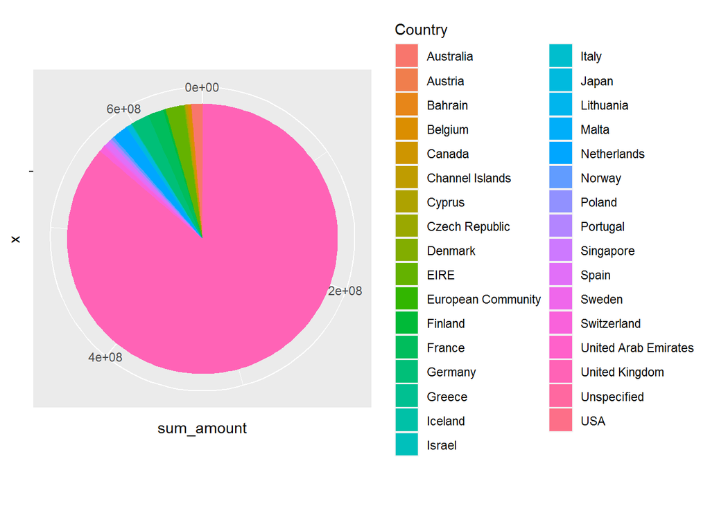

```r
ggplot(R1, aes(x="", y= sum_amount, fill=Country))+ geom_bar( stat = "identity") + coord_polar(theta = "y")
```

```r
#Ventas por  cliente
Retail %>%
group_by(CustomerID) %>%
  summarize(
    sum_amount = sum(Amount)
  ) %>%
  arrange(desc(sum_amount))
```

```
## # A tibble: 2,997 x 2
##    CustomerID sum_amount
##         <int>      <dbl>
##  1      16446   53537695
##  2      18102   30557226
##  3      14646   11971133
##  4      14911    8933816
##  5      17450    8659734
##  6      12415    7694671
##  7      17511    7378800
##  8      16029    6616354
##  9      16684    5837186
## 10      15749    5487202
## # ... with 2,987 more rows
```

```r
#Ventas por fecha
Retail %>%
  group_by(InvoiceDate) %>%
  summarize(
    sum_amount = sum(Amount, na.rm = TRUE),
  ) %>%
  arrange(desc(sum_amount))
```

```
## # A tibble: 127 x 2
##    InvoiceDate sum_amount
##    <date>           <dbl>
##  1 2011-09-12    56202749
##  2 2011-11-01    13207482
##  3 2011-05-10    12560694
##  4 2011-10-11    11769959
##  5 2011-03-10    11460066
##  6 2011-07-12    11231244
##  7 2011-03-11    10809711
##  8 2010-07-12    10627485
##  9 2011-04-11     9673284
## 10 2011-08-12     9636653
## # ... with 117 more rows
```

```r
# ticet medio
Retail %>%
  group_by(Country, CustomerID) %>%
  summarize(
    ticket_medio = mean(UnitPrice)
  ) %>%
  arrange(desc(ticket_medio))
```

```
## # A tibble: 2,999 x 3
## # Groups:   Country [33]
##    Country        CustomerID ticket_medio
##    <fct>               <int>        <dbl>
##  1 United Kingdom      13747        1594
##  2 United Kingdom      18087        1550
##  3 United Kingdom      17500        1520.
##  4 United Kingdom      15940        1519
##  5 United Kingdom      13900        1514
##  6 United Kingdom      14473        1514
##  7 United Kingdom      15759        1514
##  8 United Kingdom      16462        1514
##  9 United Kingdom      14338        1508
## 10 United Kingdom      14589        1462
## # ... with 2,989 more rows
```

## Analis de ventas por tiempo (por mes, por dia y por hora)

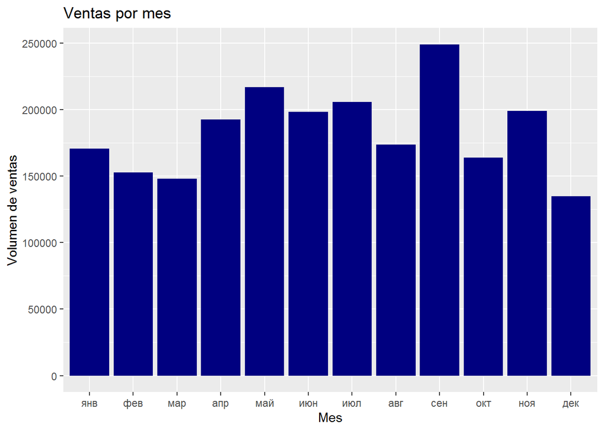

```r
Retail$Invoice_month <-month(Retail$InvoiceDate, label = TRUE)
Retail$Invoce_day <- wday(Retail$InvoiceDate, label=TRUE)
ggplot(Retail, aes(x=Invoice_month, y= Quantity)) +
  geom_bar(stat="identity", fill= "navy") +
  labs(title = "Ventas por mes", x = "Mes", y = "Volumen de ventas")
```

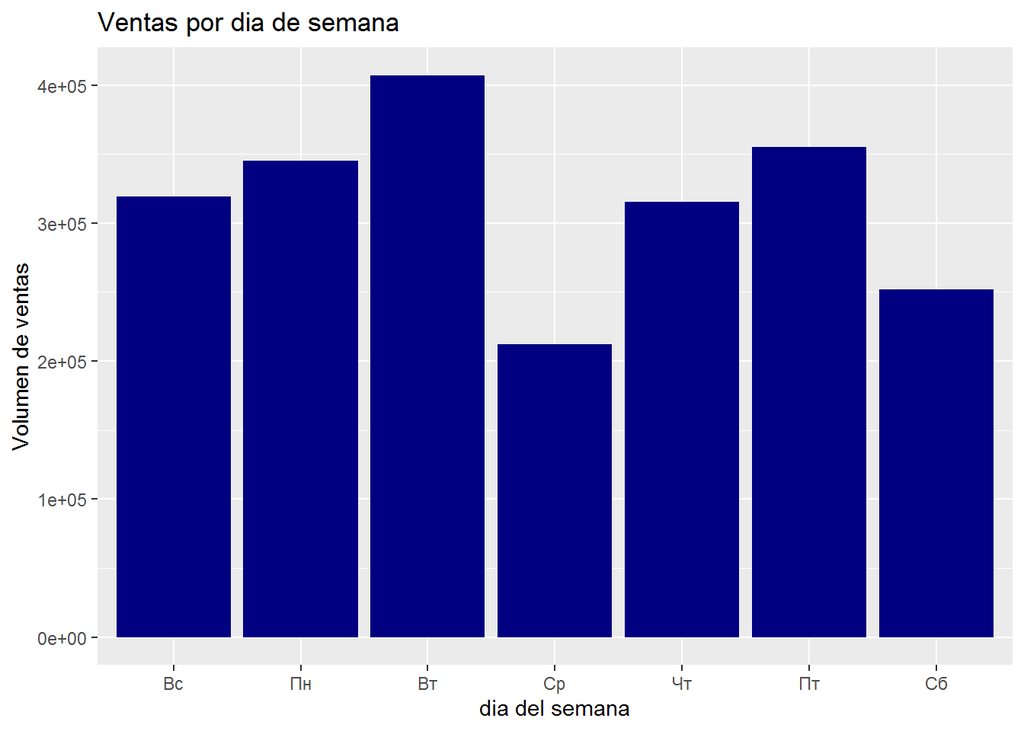

```r
ggplot(Retail, aes(x=Invoce_day , y= Quantity)) +
  geom_bar(stat="identity", fill= "navy") +
  labs(title = "Ventas por dia de semana", x = "dia del semana", y = "Volumen de ventas")
```

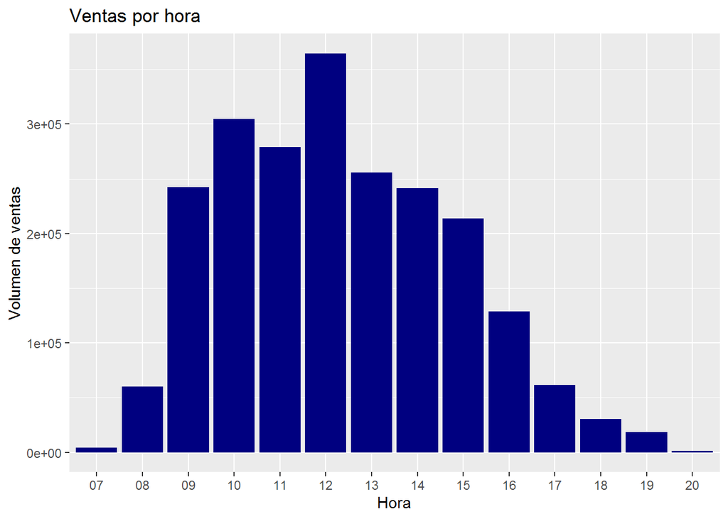

```r
Retail3<- Retail %>%
  group_by(InvoiceTime) %>%
  summarize (
    sumAmount=sum(Amount, na.rm = TRUE),
    sumQuantity=sum(Quantity, na.rm = TRUE),
    nCustomer=length(unique(CustomerID)))
names(Retail3) [1] <-"InvoiceHour"
ggplot(Retail3, aes(x=InvoiceHour, y= sumQuantity)) +
  geom_bar(stat="identity", fill= "navy") +
  labs(title = "Ventas por hora", x = "Hora", y = "Volumen de ventas")
```

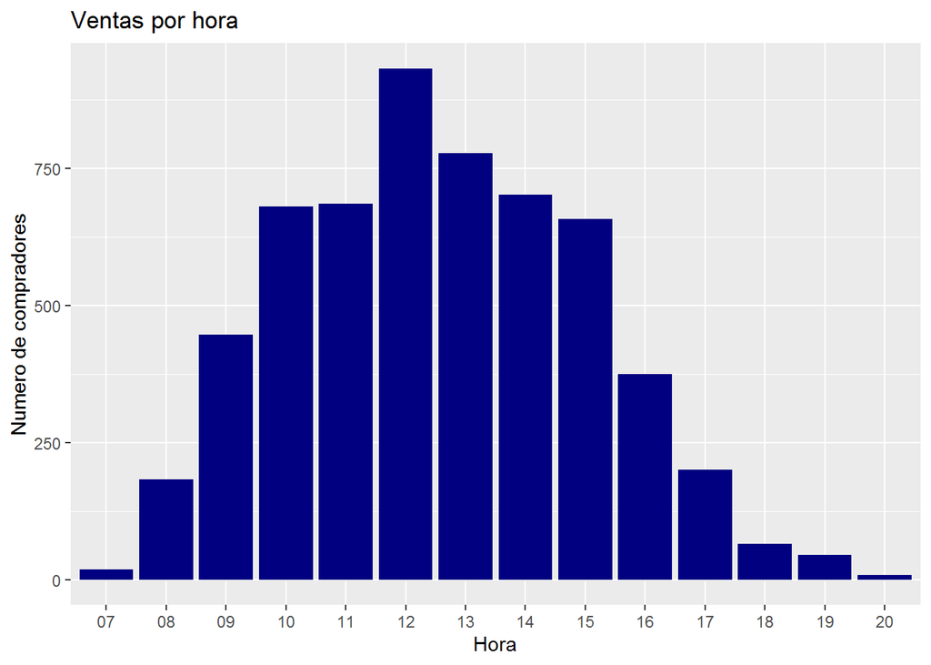

```r
ggplot(Retail3, aes(x=InvoiceHour, y= nCustomer)) +
  geom_bar(stat="identity", fill= "navy") +
  labs(title = "Ventas por hora", x = "Hora", y = "Numero de compradores")
```

## Analisis de los productos mas vendidos

```r
#Elija los pociciones mas vendidas por volumen de ventas e ingresos
Retail1 <- Retail %>%
            group_by(StockCode,Description) %>%
            summarize (
              sumAmount= sum(Amount),
              sumQuantity= sum(Quantity)
            )
head (Retail1[order(-Retail1$sumQuantity),])
```

```
## # A tibble: 6 x 4
## # Groups:   StockCode [6]
##   StockCode Description                        sumAmount sumQuantity
##   <fct>     <fct>                                  <dbl>       <int>
## 1 23843     PAPER CRAFT , LITTLE BIRDIE         53537695       80995
## 2 84077     WORLD WAR 2 GLIDERS ASSTD DESIGNS     556633       24682
## 3 85099B    JUMBO BAG RED RETROSPOT              5275376       20586
## 4 84879     ASSORTED COLOUR BIRD ORNAMENT        2158478       18065
## 5 85123A    WHITE HANGING HEART T-LIGHT HOLDER  12805784       17439
## 6 22197     POPCORN HOLDER                        919952       14831
```

```r
head(Retail1[order(-Retail1$sumAmount),] )
```

```
## # A tibble: 6 x 4
## # Groups:   StockCode [6]
##   StockCode Description                          sumAmount sumQuantity
##   <fct>     <fct>                                    <dbl>       <int>
## 1 23843     "PAPER CRAFT , LITTLE BIRDIE"         53537695       80995
## 2 85123A    "WHITE HANGING HEART T-LIGHT HOLDER"  12805784       17439
## 3 47566     "PARTY BUNTING"                        7105931        6328
## 4 21137     "BLACK RECORD COVER FRAME"             6528275        6582
## 5 22086     "PAPER CHAIN KIT 50'S CHRISTMAS "      5300040        7568
## 6 85099B    "JUMBO BAG RED RETROSPOT"              5275376       20586
```

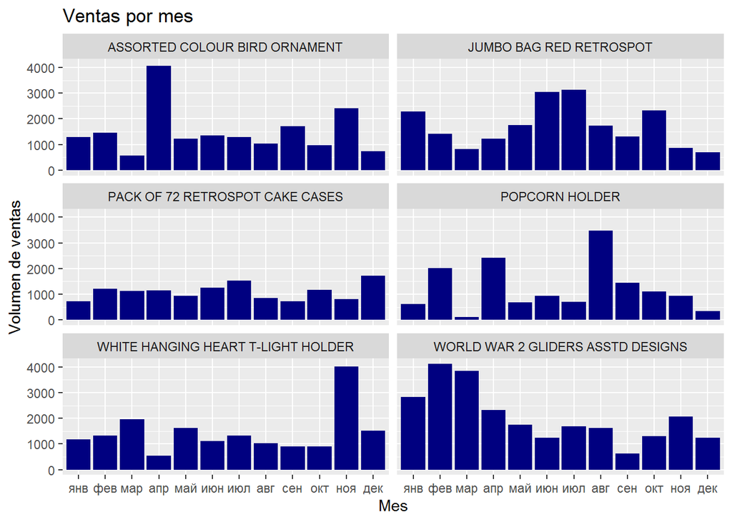

```r
Retail2 <- subset(Retail, Description%in%c("WORLD WAR 2 GLIDERS ASSTD DESIGNS","JUMBO BAG RED RETROSPOT","ASSORTED COLOUR BIRD ORNAMENT","WHITE HANGING HEART T-LIGHT HOLDER","PACK OF 72 RETROSPOT CAKE CASES","POPCORN HOLDER"), select = c(Description,InvoiceDate,InvoiceTime,Quantity,CustomerID,Amount,InvoiceNo))
Retail2$Invoice_month<-month(Retail2$InvoiceDate,label = TRUE)
Retail2$Decription<-as.character(Retail2$Description)
ggplot(Retail2, aes(x=Invoice_month, y= Quantity))+ facet_wrap(~Description, ncol=2) +
  geom_bar(stat="identity", fill= "navy") +
  labs(title = "Ventas por mes", x = "Mes", y = "Volumen de ventas")
```

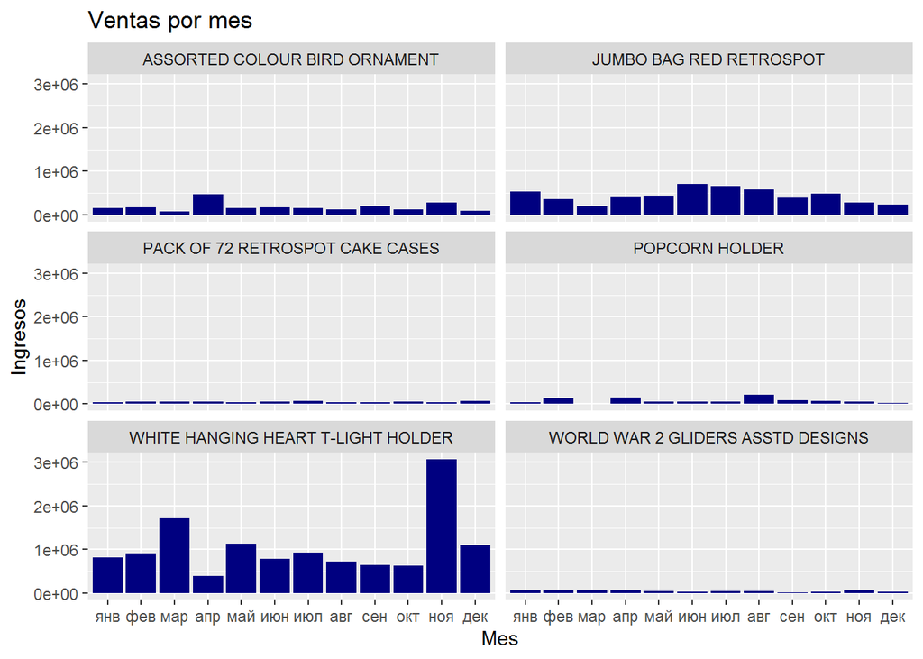

```r
ggplot(Retail2, aes(x=Invoice_month, y= Amount )) + facet_wrap(~Description, ncol=2) +
  geom_bar(stat="identity", fill= "navy" ) +
  labs(title = "Ventas por mes", x = "Mes", y = "Ingresos")
```

```r
Retail%>%group_by(InvoiceDate, CustomerID)%>%
  summarise(
    time_med = mean(InvoiceDate)
  )
```

```
## # A tibble: 7,171 x 3
## # Groups:   InvoiceDate [127]
##    InvoiceDate CustomerID time_med
##    <date>           <int> <date>
##  1 2010-01-12       12431 2010-01-12
##  2 2010-01-12       12433 2010-01-12
##  3 2010-01-12       12583 2010-01-12
##  4 2010-01-12       12662 2010-01-12
##  5 2010-01-12       12748 2010-01-12
##  6 2010-01-12       12791 2010-01-12
##  7 2010-01-12       12838 2010-01-12
##  8 2010-01-12       12868 2010-01-12
##  9 2010-01-12       12921 2010-01-12
## 10 2010-01-12       12947 2010-01-12
## # ... with 7,161 more rows
```